# lecture-06-survey-methods

## M303 Introduction to Survey Methods

FALL 2026 · LECTURE 06

M303

Introduction to Survey Methods

Choose the survey mode that fits the people, information, timing, and decision.

## Where we are

01

**Last class**  
Qualitative and observational methods

02

**Today**  
Survey methods and mode choice

03

**Coming next**  
Attitude measurement and scaling

## Learning Objectives

01

You should be able to

•

Understand the advantages of surveys and the issues associated with them

•

Understand different types of surveys and pros and cons of each type

04

Problem

05

Formulation

06

Research

07

Design

08

Data

09

Collection

10

Data Analysis &

11

Recommendation

12

Secondary Data

13

Primary Data

•

Observational and Qualitative Methods

•

Surveys

16

Sampling

## Prior-class review

01

All behaviors can be observed.

01

F

02

In order to answer "why" questions, one can use observation rather than questioning.

02

F

03

Cognitive phenomena can’t be observed.

03

T

04

A systematic process of recording behaviors without normally communicating with the people involved is called observation.

04

T

05

One can use qualitative methods in order to get a better idea about things that can’t be directly observed and/or measured.

05

T

06

Nondirective interviews are especially effective with busy executives, technical experts, and thought leaders.

06

F

07

In semi-structured or focused interviews, the respondent is given the maximum freedom to respond.

07

F

08

In symbolic analysis, the interviewer probes step by step to the question of interest.

08

F

09

When direct questions fail, one might use projective techniques.

09

T

## What information can be acquired from surveys?

01

Knowledge

•

Consumers’ awareness and knowledge about your products.

03

Attitudes

•

Consumers’ perceptions about your products and services

05

Assessments

•

Whether your marketing program/product etc. is favorable or not.

07

Decisions

•

Measuring the relationship between actions & needs, desires, preferences, motivations and goals in order to answer the “why” questions.

09

Demographics & Lifestyles

•

Age, gender, marital status, income, employment status, hobbies etc.

11

Social contacts and interactions

•

Families, friends, social groups, memberships

## Why Use Survey Research?

01

Surveys are the overwhelming choice of researchers for collecting quantitative primary data.

02

Surveys have many advantages such as

•

Cost & speed

•

Accuracy

•

Efficiency

•

Flexibility

07

Qualitative and observational methods are more likely to be used to improve and/or supplement the survey methods rather than take their place.

## What are the potential issues in surveys?

01

To obtain meaningful results:

•

The population must be defined correctly

•

The sample should represent the population

•

Selected respondents must be able and willing to cooperate

•

Respondents must have the required knowledge, opinions, attitudes, or facts

•

Respondents must understand the questions

•

The interviewer must understand and record responses correctly

## What are the types of surveys?

Surveys

**Telephone interviews**

**Self-administered surveys**

**Personal interviews**

Door-to-doorExecutiveMall interceptPurchase intercept (PIT)

**Omnibus interviews (surveys)**

**Combinations of survey methods**

## Survey method: Telephone Interviews

01

Telephone interviewing is a long-established method for obtaining information from large samples.

02

Selecting telephone numbers

•

Pre-specified list

•

A directory

•

Random dialing procedure

•

Random digit dialing

•

Systematic random digit dialing (SRDD)

•

Plus-one dialing

•

Listed number 314-327-2989 → you call 314-327-2990

☎

NUMBER FRAME**List · directory · random digits**

→

CONTACT**Call · screen · callback**

## What are the pros of Telephone Interviews?

01

More interviews can be conducted in a given time period

•

Travel time is saved

03

More hours of the day/week are productive

04

Less sample bias due to nonresponse

•

Ease of callbacks at lower cost (WATS)

## What are the cons of Telephone Interviews?

01

Inability to employ visual aids or complex tasks

02

Interviewer must rely solely on verbal cues to judge the reaction and understanding of respondents

03

Cannot be longer than 5–10 minutes, or the respondent may lose interest

•

Relatively little data can be collected

05

A capable interviewer is essential

06

Potential for sample bias

•

Coverage gaps: unreachable people, unlisted numbers, and mobile-only or screened-call populations

## Survey method: Self-Administered Surveys

01

No interviewer involved

02

The survey is distributed by email, mail, fax, or by hand

▣

Email linkWeb formPaper mailHand delivery

ONE PRINCIPLE**The respondent completes it without an interviewer.**

## How to conduct Self-Administered Surveys?

01

The method of contact should be determined

02

Cover letter should be prepared

03

Questionnaire length, content, layout, color, and format should be chosen

04

Incentives might be given to increase the response rates

05

Submitting responses should be easy for the respondent

## What is the response rate in Self-Administered Surveys?

01

Low survey quality => low response rate => sample bias

02

Example: If you contacted 1,000 participants and the response rate is 5%, then what is the number of complete surveys?

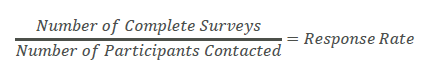

## What are the factors affecting the Response Rate?

01

Perceived amount of work required.

•

Long surveys → low response rate

•

Difficult surveys → low response rate

04

Intrinsic interest in the topic

•

Low-interest topics → low response rate

06

Level of motivation

•

Monetary incentives → high response rate

08

Characteristics of the sample

## What are the pros of self-administered surveys?

01

Lower cost

02

Larger samples

03

Time savings

04

No interviewer bias

05

Survey answered at the respondent’s discretion

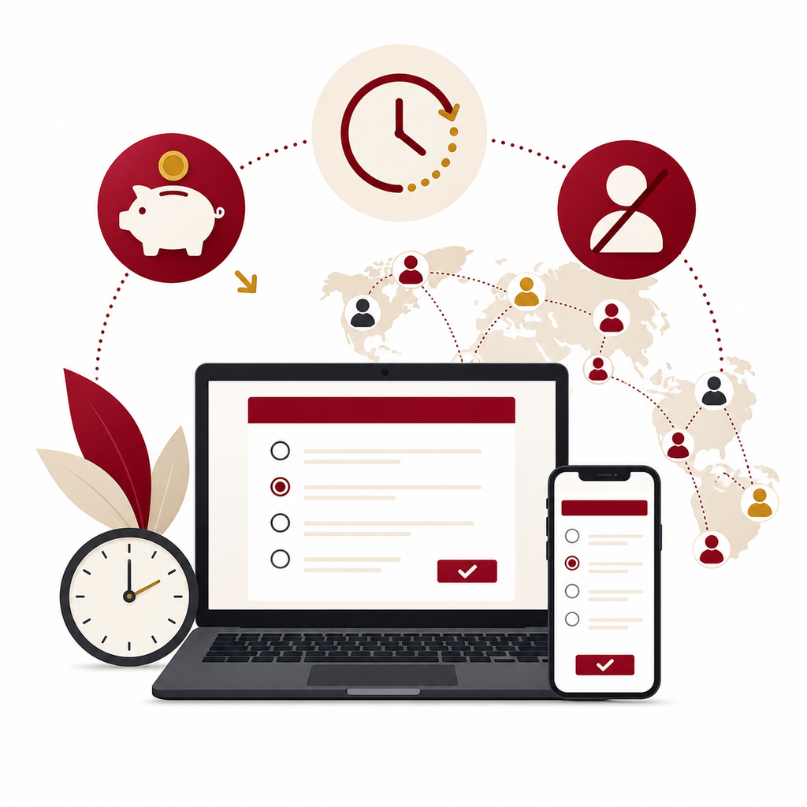

## What are the cons of self-administered surveys?

01

The absence of an interviewer provides limited control over

•

Understanding the identity of respondents

•

Whom the respondent might consult for help in understanding the questions

•

The speed of the response

•

The order in which the questions are presented and answered

## Survey method: Personal Interviews

01

A face-to-face survey method.

02

The personal interview process is characterized by the interaction of four entities.

01**Researcher**

**→**

02**Interviewer**

**→**

03**Respondent**

**↔**

04**Interview environment**

## What are the types of Personal Interviews?

01

Door-to-door interviewing

•

Interviews with respondents in their homes

03

Executive interviewing

•

Interviews with business people at their offices

05

Mall-intercept interviews

•

Interviews with mall shoppers in shopping centers

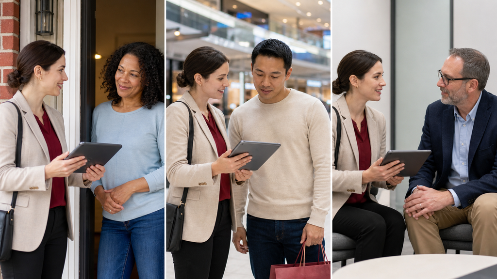

## What are the types of Personal Interviews?

01

Purchase-intercept technique

•

Interviews with customers after observing them make purchases in stores

03

Omnibus surveys

•

Regularly scheduled interviews/surveys with questions provided by a number of separate clients

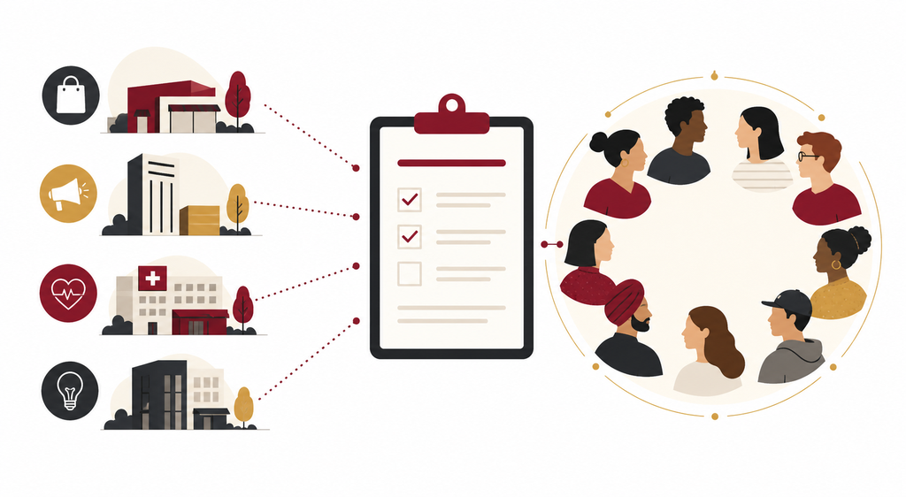

01 · OBSERVE**Purchase****→**02 · APPROACH**Customer****→**03 · INTERVIEW**Immediately afterward**

## What are the pros and cons of different personal-interview types?

01

Door-to-Door interviewing

02

Executive interviewing

03

Omnibus surveys

04

Purchase intercept technique

05

Mall intercept surveys

06

Advantages and Disadvantages of Each Interview Type

07

Respondents’ buying experiences are salient

08

Respondents may not be a representative sample

09

Very expensive to set up meetings

10

The interviewer has to go to the respondent’s office

11

Long waiting time and cancellations are common

12

Relatively lower costs

13

Respondents may not be a representative sample

14

Low costs – clients share costs

15

Good solution if questions are limited and more standard

16

Suitable for tracking periodically and before-after studies

17

Relatively expensive

18

Comfortable environment for respondents

19

Extensive illustrations and in-depth explanations are possible

20

Viable way for in-home product tests

## What are the pros of Personal Interviews?

01

Can arouse and keep interest

02

Ask complex questions with the help of visual and other aids

03

Clarify misunderstandings

04

High degree of flexibility

05

Good for neutral questions

## What are the cons of Personal Interviews?

01

Respondent and interviewer biases

02

Lack of respondent anonymity

03

Embarrassing/personal questions

04

Time Requirements

05

Cost per completed interview is high

06

Trained interviewers (geographically near the sample) are required

## When should you use Personal Interviews?

01

A large amount of information per respondent

02

Complex questions

03

Required tasks

•

Product test

05

No other choices

•

No phone number

•

No mailing address

•

No email address

## Survey method: Combination of Survey Methods

01

Each survey method has different pros and cons, therefore, a combination of survey methods can retain the best features while minimizing the limitations.

•

Example: Telephone pre-notification approach

## What is Telephone Pre-notification?

01

Call to ask permission before mailing the survey

02

Advantages

•

Gain agreement

•

Signals that the respondent is serious about cooperating

05

Disadvantages

•

Requires both telephone numbers and mailing addresses for respondents.

07

Agreement

01 · CALL**Ask permission**

→

02 · SEND**Mail or email the survey**

→

03 · COMPLETE**Respondent follows through**

## What is Lockbox Approach?

01

Mail a locked box containing the questionnaire and a gift; the lock combination or PIN is provided immediately before the interview.

02

The resulting curiosity can produce response rates as high as 50% to 70%.

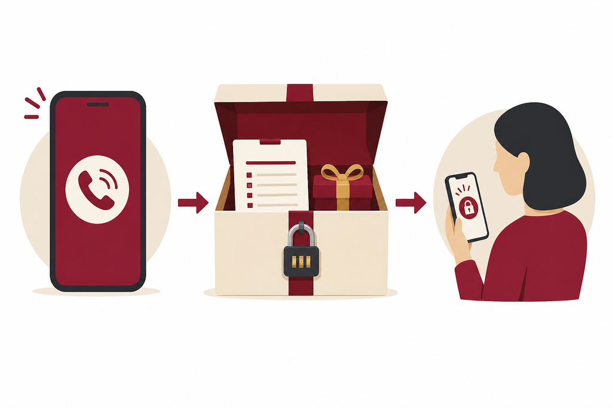

## How to choose a survey method?

01

Type of population – reading and writing skills, motivation to cooperate

02

Sampling – how to draw a representative sample

03

Questions – complex vs. easy, general vs. sensitive

04

Response rates

05

Costs

•

Available facilities and trained interviewers

•

Duration of data collection

## Today’s Class: Quiz

01

Surveys can be used to understand consumers' perceptions about products and services.

01

T

02

Surveys can be used to collect information about consumer demographics and lifestyles.

02

T

03

Four advantages of surveys are their low cost, high accuracy, efficiency and flexibility.

03

T

04

Qualitative methods can easily be used to replace surveys.

04

F

05

In order to obtain meaningful results from a survey, one has to define the population of interest correctly.

05

T

06

In a telephone survey, one might use phone directories to select the telephone numbers to call.

06

T

07

The cost of telephone interviews is typically higher than face-to-face interviews.

07

F

08

If one wants to employ visual aids or complex tasks, face-to-face interviews become the best survey method.

08

T

## Today’s class: quiz (continued)

01

In telephone interviews, the interviewer must rely solely on verbal cues to judge the reaction and understanding of respondents.

01

T

02

If you contacted 1,000 participants and the response rate is 10%, then the number of complete surveys should be 100.

02

T

03

The response rate in a self-administered survey decreases as the survey becomes longer.

03

T

04

Door to door interviewing refers to interviews with mall shoppers in shopping centers.

04

F

05

In an omnibus survey, multiple clients have sections of questions in the survey; this way the cost of conducting the survey is shared among these clients.

05

T

06

Among the personal interview methods, the most costly one is the mall intercept surveys.

06

F

07

If you do not have any contact information such as phone numbers, mailing and email addresses, personal interviews become the feasible survey method.

07

T

08

In the telephone pre-notification method, you call to ask the respondent's permission before mailing the survey.

08

T

## To sum up

01

Surveys

•

Pros

•

Limitations

04

Types of surveys and their pros and cons

•

Telephone interviews

•

Self-administered surveys

•

Personal interviews

•

Door-to-door, executive, mall intercept, purchase intercept, omnibus

•

Combination of survey methods

## Next class

01

Exam 1 — check Canvas for the schedule

02

Next topic — Attitude Measurement and Scaling